# Model Evaluation

```python
%matplotlib notebook
import warnings; warnings.simplefilter('ignore')

import numpy as np
import pandas as pd
import seaborn as sns
import matplotlib.pyplot as plt
```

## Learning objectives

- Understand why **accuracy** only gives a partial picture of a classifier's performance.
- Understand the motivation and definition of important **evaluation metrics** in machine learning.
- Learn how to use a variety of evaluation metrics to **evaluate supervised** machine learning models.
- Learn about choosing the right metric for **selecting between models** or for doing **parameter tuning**.

## Represent / Train / Evaluate / Refine Cycle

[figure not shown]

## Evaluation Goal

- Different applications have very **different goals**
- **Accuracy** is widely used, but many others are possible, e.g.:
  - User satisfaction (Web search)
  - Amount of revenue (e-commerce)
  - Increase in patient survival rates (medical)
- It's very important to choose evaluation methods that **match the goal** of your application.
- Compute your selected evaluation metric for multiple **different models**.
- Then select the model with **'best'** value of evaluation metric.

## Evaluation for Classification

### Classification Accuracy and Error Rate

- Classification Accuracy: is the percentage of correctly classified examples over all training examples

  ```
    𝐴𝑐𝑐𝑢𝑟𝑎𝑐𝑦=  (𝑁𝑜. 𝑐𝑜𝑟𝑟𝑒𝑐𝑡𝑙𝑦 𝑐𝑙𝑎𝑠𝑠𝑖𝑓𝑖𝑒𝑑 𝑒𝑥𝑎𝑚𝑝𝑙𝑒𝑠)/(𝑁𝑜. 𝑎𝑙𝑙 𝑒𝑥𝑎𝑚𝑝𝑙𝑒𝑠)
  ```

  Often also referred to as recognition rate
- Error rate (or misclassification rate) is the opposite of accuracy.

  ```
    𝐸𝑟𝑟𝑜𝑟 𝑟𝑎𝑡𝑒=1 −𝑎𝑐𝑐𝑢𝑟𝑎𝑐𝑦
  ```

### Accuracy with imbalanced classes

the classification rate can be misleading! Example:

```python
from sklearn.datasets import load_digits

dataset = load_digits()
X, y = dataset.data, dataset.target

for class_name, class_count in zip(dataset.target_names, np.bincount(dataset.target)):
    print(class_name,class_count)
```

```
0 178
1 182
2 177
3 183
4 181
5 182
6 181
7 179
8 174
9 180
```

Creating a dataset with imbalanced binary classes:

- Negative class (0) is 'not digit 1'
- Positive class (1) is 'digit 1'

```python
y_binary_imbalanced = y.copy()
y_binary_imbalanced[y_binary_imbalanced != 1] = 0

print('Original labels:\t', y[1:30])
print('New binary labels:\t', y_binary_imbalanced[1:30])
```

```
Original labels:	 [1 2 3 4 5 6 7 8 9 0 1 2 3 4 5 6 7 8 9 0 1 2 3 4 5 6 7 8 9]
New binary labels:	 [1 0 0 0 0 0 0 0 0 0 1 0 0 0 0 0 0 0 0 0 1 0 0 0 0 0 0 0 0]
```

```python
np.bincount(y_binary_imbalanced)    # Negative class (0) is the most frequent class
```

```
array([1615,  182], dtype=int64)
```

```python
from sklearn.model_selection import train_test_split
X_train, X_test, y_train, y_test = train_test_split(X, y_binary_imbalanced, random_state=0)

# Accuracy of Support Vector Machine classifier
from sklearn.svm import SVC

svm = SVC(kernel='rbf', C=1).fit(X_train, y_train)
svm.score(X_test, y_test)
```

```
0.9088888888888889
```

### Dummy Classifiers

Dummy classifiers completely ignore the input data!

```python
from sklearn.dummy import DummyClassifier

# Negative class (0) is most frequent
dummy_majority = DummyClassifier(strategy = 'most_frequent').fit(X_train, y_train)
# Therefore the dummy 'most_frequent' classifier always predicts class 0
y_dummy_predictions = dummy_majority.predict(X_test)

y_dummy_predictions
```

[output not shown]

```python
dummy_majority.score(X_test, y_test)
```

```
0.9044444444444445
```

- Dummy classifiers serve as a sanity check on your classifier's performance.
- They provide a null metric (e.g. null accuracy) baseline.
- Dummy classifiers should not be used for real problems.

Some commonly-used settings for the strategy parameter for DummyClassifier in scikit-learn:

- most_frequent : predicts the most frequent label in the training set.
- stratified : random predictions based on training set class distribution.
- uniform : generates predictions uniformly at random.
- constant : always predicts a constant label provided by the user.

*What if my classifier accuracy is close to the null accuracy baseline?*  
This could be a sign of:

- Ineffective, erroneous or missing **features**
- Poor choice of kernel or **hyperparameter**
- Large class **imbalance**

```python
svm = SVC(kernel='linear', C=1).fit(X_train, y_train)
svm.score(X_test, y_test)
```

```
0.9777777777777777
```

### Confusion matrices

[figure not shown]

#### Binary (two-class) confusion matrix

```python
def print_cm(cm, labels, hide_zeroes=False, hide_diagonal=False, hide_threshold=None):
    """pretty print for confusion matrixes"""
    columnwidth = max([len(x) for x in labels] + [5])  # 5 is value length
    empty_cell = " " * columnwidth
    # Print header
    print("    " + empty_cell, end=" ")
    for label in labels:
        print("%{0}s".format(columnwidth) % label, end=" ")
    print()
    # Print rows
    for i, label1 in enumerate(labels):
        print("    %{0}s".format(columnwidth) % label1, end=" ")
        for j in range(len(labels)):
            cell = "%{0}.1f".format(columnwidth) % cm[i, j]
            if hide_zeroes:
                cell = cell if float(cm[i, j]) != 0 else empty_cell
            if hide_diagonal:
                cell = cell if i != j else empty_cell
            if hide_threshold:
                cell = cell if cm[i, j] > hide_threshold else empty_cell
            print(cell, end=" ")
        print()
```

```python
from sklearn.metrics import confusion_matrix

# Negative class (0) is most frequent
dummy_majority = DummyClassifier(strategy = 'most_frequent').fit(X_train, y_train)
y_majority_predicted = dummy_majority.predict(X_test)

confusion = confusion_matrix(y_test, y_majority_predicted)

print('Most frequent class (dummy classifier)\n')
print_cm(confusion, ['Not one', 'One'])
```

```
Most frequent class (dummy classifier)

            Not one     One
    Not one   407.0     0.0
        One    43.0     0.0
```

```python
# produces random predictions w/ same class proportion as training set
dummy_classprop = DummyClassifier(strategy='stratified').fit(X_train, y_train)
y_classprop_predicted = dummy_classprop.predict(X_test)
confusion = confusion_matrix(y_test, y_classprop_predicted)

print('Random class-proportional prediction (dummy classifier)\n')
print_cm(confusion, ['Not one', 'One'])
```

```
Random class-proportional prediction (dummy classifier)

            Not one     One
    Not one   367.0    40.0
        One    39.0     4.0
```

```python
svm = SVC(kernel='rbf', C=1).fit(X_train, y_train)
svm_predicted = svm.predict(X_test)
confusion = confusion_matrix(y_test, svm_predicted)

print('Support vector machine classifier (linear kernel, C=1)\n')
print_cm(confusion, ['Not one', 'One'])
```

```
Support vector machine classifier (linear kernel, C=1)

            Not one     One
    Not one   407.0     0.0
        One    41.0     2.0
```

```python
svm = SVC(kernel='linear', C=1).fit(X_train, y_train)
svm_predicted = svm.predict(X_test)
confusion = confusion_matrix(y_test, svm_predicted)

print('Support vector machine classifier (linear kernel, C=1)\n')
print_cm(confusion, ['Not one', 'One'])
```

```
Support vector machine classifier (linear kernel, C=1)

            Not one     One
    Not one   402.0     5.0
        One     5.0    38.0
```

```python
from sklearn.linear_model import LogisticRegression

lr = LogisticRegression().fit(X_train, y_train)
lr_predicted = lr.predict(X_test)
confusion = confusion_matrix(y_test, lr_predicted)

print('Logistic regression classifier (default settings)\n')
print_cm(confusion, ['Not one', 'One'])
```

```
Logistic regression classifier (default settings)

            Not one     One
    Not one   401.0     6.0
        One     6.0    37.0
```

```python
from sklearn.tree import DecisionTreeClassifier

dt = DecisionTreeClassifier(max_depth=2).fit(X_train, y_train)
tree_predicted = dt.predict(X_test)
confusion = confusion_matrix(y_test, tree_predicted)

print('Decision tree classifier (max_depth = 2)\n')
print_cm(confusion, ['Not one', 'One'])
```

```
Decision tree classifier (max_depth = 2)

            Not one     One
    Not one   400.0     7.0
        One    17.0    26.0
```

### Evaluation metrics for binary classification

[figure not shown]

#### Precision

[figure not shown]

- The precision of predicting positive examples.
- How many of the predicted positive examples are really positive

#### Recall

[figure not shown]

- How much did the classifier recall of the positive examples
- aka. True Positive Rate (TPR), and Sensitivity

#### F1

[figure not shown]

There is also

[figure not shown]

- True negative rate
- The ability to correctly classify the negative class!

```python
from sklearn.metrics import accuracy_score, precision_score, recall_score, f1_score

print('Accuracy: {:.2f}'.format(accuracy_score(y_test, tree_predicted)))
print('Precision: {:.2f}'.format(precision_score(y_test, tree_predicted)))
print('Recall: {:.2f}'.format(recall_score(y_test, tree_predicted)))
print('F1: {:.2f}'.format(f1_score(y_test, tree_predicted)))
```

```
Accuracy: 0.95
Precision: 0.79
Recall: 0.60
F1: 0.68
```

```python
# Combined report with all above metrics
from sklearn.metrics import classification_report

print(classification_report(y_test, tree_predicted, target_names=['not 1', '1']))
```

```
              precision    recall  f1-score   support

       not 1       0.96      0.98      0.97       407
           1       0.79      0.60      0.68        43

   micro avg       0.95      0.95      0.95       450
   macro avg       0.87      0.79      0.83       450
weighted avg       0.94      0.95      0.94       450
```

- **"micro"** gives each sample-class pair an equal contribution to the overall metric (except as a result of sample-weight). Rather than summing the metric per class,
- **"macro"** simply calculates the mean of the binary metrics, giving equal weight to each class.  
  In problems where infrequent classes are nonetheless important, macro-averaging may be a means of highlighting their performance. On the other hand, the assumption that all classes are equally important is often untrue, such that macro-averaging will over-emphasize the typically low performance on an infrequent class.
- **"weighted"** accounts for class imbalance by computing the average of binary metrics in which each class’s score is weighted by its presence in the true data sample.  
  (check slides in (applied machine learning in python))

```python
print('Random class-proportional (dummy)\n',
      classification_report(y_test, y_classprop_predicted, target_names=['not 1', '1']))
print("---------------------------------------------------------")
print('SVM\n',
      classification_report(y_test, svm_predicted, target_names = ['not 1', '1']))
print("---------------------------------------------------------")
print('Logistic regression\n',
      classification_report(y_test, lr_predicted, target_names = ['not 1', '1']))
print("---------------------------------------------------------")
print('Decision tree\n',
      classification_report(y_test, tree_predicted, target_names = ['not 1', '1']))
print("---------------------------------------------------------")
```

```
Random class-proportional (dummy)
               precision    recall  f1-score   support

       not 1       0.90      0.90      0.90       407
           1       0.09      0.09      0.09        43

   micro avg       0.82      0.82      0.82       450
   macro avg       0.50      0.50      0.50       450
weighted avg       0.83      0.82      0.83       450

---------------------------------------------------------
SVM
               precision    recall  f1-score   support

       not 1       0.99      0.99      0.99       407
           1       0.88      0.88      0.88        43

   micro avg       0.98      0.98      0.98       450
   macro avg       0.94      0.94      0.94       450
weighted avg       0.98      0.98      0.98       450

---------------------------------------------------------
Logistic regression
               precision    recall  f1-score   support

       not 1       0.99      0.99      0.99       407
           1       0.86      0.86      0.86        43

   micro avg       0.97      0.97      0.97       450
   macro avg       0.92      0.92      0.92       450
weighted avg       0.97      0.97      0.97       450

---------------------------------------------------------
Decision tree
               precision    recall  f1-score   support

       not 1       0.96      0.98      0.97       407
           1       0.79      0.60      0.68        43

   micro avg       0.95      0.95      0.95       450
   macro avg       0.87      0.79      0.83       450
weighted avg       0.94      0.95      0.94       450

---------------------------------------------------------
```

### Trading Off Precision and Recall

Can be achieved by e.g. varying decision **threshold** of a classifier.

- Suppose we want to predict only if very **confident**
  - Avoid false positives.
  - Higher threshold, higher precision, lower recall.
- Suppose we want to **avoid missing** positive examples (e.g. highly contagious disease)
  - Avoid false negatives.
  - Lower threshold, lower precision, higher recall.
- **Recall-oriented machine learning tasks**:
  - Search and information extraction in legal discovery
  - Tumor detection
  - Often paired with a human expert to filter out false positives
- **Precision-oriented machine learning tasks**:
  - Search engine ranking, query suggestion
  - Document classification
  - Many customer-facing tasks (users remember failures!)

### Decision functions

- Each **classifier score** value per test point indicates how confidently the classifier predicts the positive class (large-magnitude positive values) or the negative class (large-magnitude negative values).
- Choosing a fixed decision **threshold** gives a classification rule.

```python
X_train, X_test, y_train, y_test = train_test_split(X, y_binary_imbalanced, random_state=0)

y_scores_lr = lr.fit(X_train, y_train).decision_function(X_test)
y_score_list = list(zip(y_test[0:20], y_scores_lr[0:20]))

# show the decision_function scores for first 20 instances
y_score_list
```

```
[(0, -23.177190659057413),
 (0, -13.541499275924934),
 (0, -21.722931392118863),
 (0, -18.907331592939087),
 (0, -19.735710477993003),
 (0, -9.749881951500523),
 (1, 5.234934901586263),
 (0, -19.307654905146972),
 (0, -25.101179084160105),
 (0, -21.827293939603223),
 (0, -24.151385315482127),
 (0, -19.57697045677537),
 (0, -22.574536340741492),
 (0, -10.823178014466372),
 (0, -11.91199599279311),
 (0, -10.979093931056003),
 (1, 11.206094761125225),
 (0, -27.64601060941326),
 (0, -12.859207350646066),
 (0, -25.848766509204186)]
```

```python
X_train, X_test, y_train, y_test = train_test_split(X, y_binary_imbalanced, random_state=0)
y_proba_lr = lr.fit(X_train, y_train).predict_proba(X_test)
y_proba_list = list(zip(y_test[0:20], y_proba_lr[0:20,1]))

# show the probability of positive class for first 20 instances
y_proba_list
```

```
[(0, 8.595556329003577e-11),
 (0, 1.3152279108008344e-06),
 (0, 3.6800249698884413e-10),
 (0, 6.146816084115751e-09),
 (0, 2.6846633981073727e-09),
 (0, 5.8298146862571315e-05),
 (1, 0.994701057113338),
 (0, 4.119002109861467e-09),
 (0, 1.2551523237968057e-11),
 (0, 3.315329415875665e-10),
 (0, 3.24479024110104e-11),
 (0, 3.1465146408233984e-09),
 (0, 1.570375227232466e-10),
 (0, 1.9931723568128993e-05),
 (0, 6.709388778888975e-06),
 (0, 1.7054252267886335e-05),
 (1, 0.9999864090761522),
 (0, 9.851222897501183e-13),
 (0, 2.6020526264294253e-06),
 (0, 5.943240995520533e-12)]
```

### Precision-recall curves

- uses the *decision function's results
- By **sweeping the decision threshold** through the entire range of possible score values, we get a series of classification outcomes that form a **curve**

[output not shown]

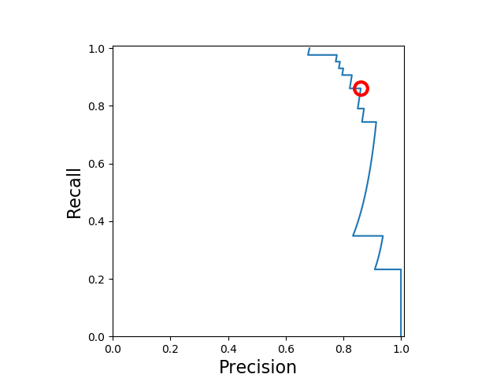

```python
from sklearn.metrics import precision_recall_curve

precision, recall, thresholds = precision_recall_curve(y_test, y_scores_lr)
# index of the closest threshold value to zero (the one we used) (argmin returns the indices of the minimum values)
closest_zero = np.argmin(np.abs(thresholds))
closest_zero_p = precision[closest_zero]
closest_zero_r = recall[closest_zero]

plt.figure()
plt.xlim([0.0, 1.01])
plt.ylim([0.0, 1.01])
plt.plot(precision, recall, label='Precision-Recall Curve')
plt.plot(closest_zero_p, closest_zero_r, 'o', markersize = 12, fillstyle = 'none', c='r', mew=3)
plt.xlabel('Precision', fontsize=16)
plt.ylabel('Recall', fontsize=16)
plt.axes().set_aspect('equal')
plt.show()
```

- X-axis: Precision, Y-axis: Recall
- Top right corner: The “ideal” point
  - Precision = 1.0
  - Recall = 1.0
- **“Steepness”** (having an almost vertical slope) of P-R curves is important:
  - *Maximize* precision
  - while *maximizing* recall

### ROC curves, Area-Under-Curve (AUC)

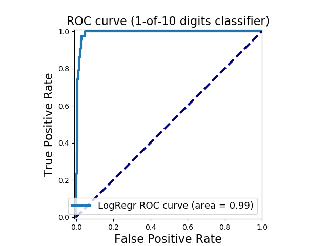

```python
from sklearn.metrics import roc_curve, auc

X_train, X_test, y_train, y_test = train_test_split(X, y_binary_imbalanced, random_state=0)

y_score_lr = lr.fit(X_train, y_train).decision_function(X_test)
fpr_lr, tpr_lr, _ = roc_curve(y_test, y_score_lr)
roc_auc_lr = auc(fpr_lr, tpr_lr)

plt.figure()
plt.xlim([-0.01, 1.00])
plt.ylim([-0.01, 1.01])
plt.plot(fpr_lr, tpr_lr, lw=3, label='LogRegr ROC curve (area = {:0.2f})'.format(roc_auc_lr))
plt.xlabel('False Positive Rate', fontsize=16)
plt.ylabel('True Positive Rate', fontsize=16)
plt.title('ROC curve (1-of-10 digits classifier)', fontsize=16)
plt.legend(loc='lower right', fontsize=13)
plt.plot([0, 1], [0, 1], color='navy', lw=3, linestyle='--')
plt.axes().set_aspect('equal')
plt.show()
```

- X-axis: False Positive Rate, Y-axis: True Positive Rate
- Top left corner: • The “ideal” point
  - False positive rate of zero
  - True positive rate of one
- **“Steepness”** of ROC curves is important:
  - *Maximize* the true positive rate
  - while *minimizing* the false positive rate

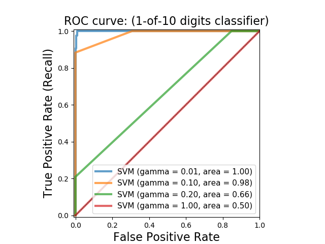

```
gamma = 0.01  accuracy = 0.91   AUC = 1.00
gamma = 0.10  accuracy = 0.90   AUC = 0.98
gamma = 0.20  accuracy = 0.90   AUC = 0.66
gamma = 1.00  accuracy = 0.90   AUC = 0.50
```

```python
from matplotlib import cm

X_train, X_test, y_train, y_test = train_test_split(X, y_binary_imbalanced, random_state=0)

plt.figure()
plt.xlim([-0.01, 1.00])
plt.ylim([-0.01, 1.01])
for g in [0.01, 0.1, 0.20, 1]:
    svm = SVC(gamma=g).fit(X_train, y_train)
    y_score_svm = svm.decision_function(X_test)
    fpr_svm, tpr_svm, _ = roc_curve(y_test, y_score_svm)
    roc_auc_svm = auc(fpr_svm, tpr_svm)
    accuracy_svm = svm.score(X_test, y_test)
    print("gamma = {:.2f}  accuracy = {:.2f}   AUC = {:.2f}".format(g, accuracy_svm,
                                                                    roc_auc_svm))
    plt.plot(fpr_svm, tpr_svm, lw=3, alpha=0.7,
             label='SVM (gamma = {:0.2f}, area = {:0.2f})'.format(g, roc_auc_svm))

plt.xlabel('False Positive Rate', fontsize=16)
plt.ylabel('True Positive Rate (Recall)', fontsize=16)
plt.plot([0, 1], [0, 1], color='k', lw=0.5, linestyle='--')
plt.legend(loc="lower right", fontsize=11)
plt.title('ROC curve: (1-of-10 digits classifier)', fontsize=16)
plt.axes().set_aspect('equal')

plt.show()
```

#### Summarizing an ROC curve in one number: Area Under the Curve (AUC)

AUC = 0.5 (worst) AUC = 1 (best)

- AUC can be interpreted as:
  1. The total area under the ROC curve.
  2. The probability that the classifier will assign a higher score to a randomly chosen positive example than to a randomly chosen negative example.
- Advantages:
  - Gives a single number for easy comparison.
  - Does not require specifying a decision threshold.
- Drawbacks:
  - As with other single-number metrics, AUC loses information, e.g. about tradeoffs and the shape of the ROC curve.

### Evaluation measures for multi-class classification

Multi-class evaluation is an extension of the binary case.

- A collection of true vs predicted binary outcomes, one per class
- Confusion matrices are especially useful
- Classification report
- Overall evaluation metrics are averages across classes

#### Multi-class confusion matrix

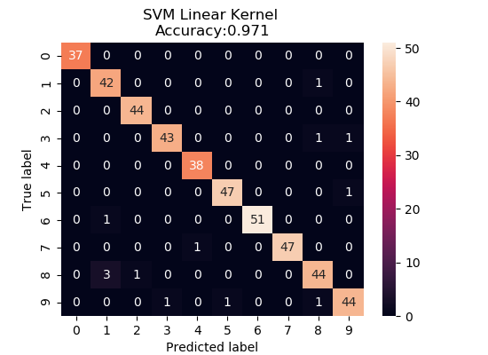

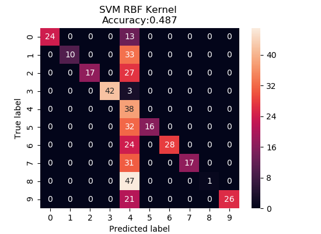

```python
dataset = load_digits()
X, y = dataset.data, dataset.target
X_train_mc, X_test_mc, y_train_mc, y_test_mc = train_test_split(X, y, random_state=0)


svm = SVC(kernel = 'linear').fit(X_train_mc, y_train_mc)
svm_predicted_mc = svm.predict(X_test_mc)
# make confusion matrix
confusion_mc = confusion_matrix(y_test_mc, svm_predicted_mc)
# put it in data frame to visualize
df_cm = pd.DataFrame(confusion_mc,
                     index = [i for i in range(0,10)], columns = [i for i in range(0,10)])

plt.figure(figsize=(5.5,4))
sns.heatmap(df_cm, annot=True)
plt.title('SVM Linear Kernel \nAccuracy:{0:.3f}'.format(accuracy_score(y_test_mc,
                                                                       svm_predicted_mc)))
plt.ylabel('True label')
plt.xlabel('Predicted label')


svm = SVC(kernel = 'rbf').fit(X_train_mc, y_train_mc)
svm_predicted_mc = svm.predict(X_test_mc)
confusion_mc = confusion_matrix(y_test_mc, svm_predicted_mc)
df_cm = pd.DataFrame(confusion_mc, index = [i for i in range(0,10)],
                  columns = [i for i in range(0,10)])

plt.figure(figsize = (5.5,4))
sns.heatmap(df_cm, annot=True)
plt.title('SVM RBF Kernel \nAccuracy:{0:.3f}'.format(accuracy_score(y_test_mc,
                                                                    svm_predicted_mc)))
plt.ylabel('True label')
plt.xlabel('Predicted label');
```

#### Multi-class classification report

```python
print(classification_report(y_test_mc, svm_predicted_mc))
```

```
              precision    recall  f1-score   support

           0       1.00      0.65      0.79        37
           1       1.00      0.23      0.38        43
           2       1.00      0.39      0.56        44
           3       1.00      0.93      0.97        45
           4       0.14      1.00      0.25        38
           5       1.00      0.33      0.50        48
           6       1.00      0.54      0.70        52
           7       1.00      0.35      0.52        48
           8       1.00      0.02      0.04        48
           9       1.00      0.55      0.71        47

   micro avg       0.49      0.49      0.49       450
   macro avg       0.91      0.50      0.54       450
weighted avg       0.93      0.49      0.54       450
```

### Regression evaluation metrics

- Typically r2_score is enough Reminder: computes how well future instances will be predicted

  ```
    - Best possible score is 1.0
    - Constant prediction score is 0.0
  ```

- Alternative metrics include:
  - mean_absolute_error (absolute difference of target & predicted values)
  - mean_squared_error (squared difference of target & predicted values)

*Dummy regressors* strategy parameter options:

- mean : predicts the mean of the training targets.
- median : predicts the median of the training targets.
- quantile : predicts a user-provided quantile of the training target values (e.g. value at the 75th percentile)
- constant : predicts a constant user-provided value.

```
Linear model, coefficients:  [-698.80206267]
Mean squared error (dummy): 4965.13
Mean squared error (linear model): 4646.74
r2_score (dummy): -0.00
r2_score (linear model): 0.06
```

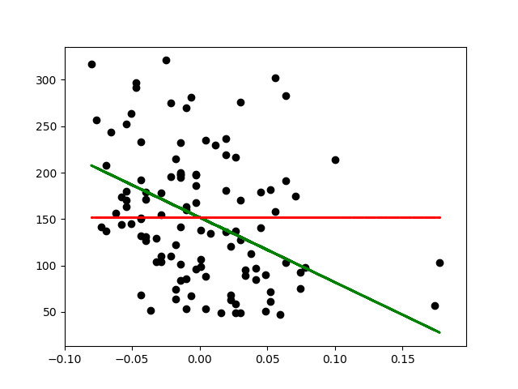

```python
%matplotlib notebook
import matplotlib.pyplot as plt
import numpy as np
from sklearn.model_selection import train_test_split
from sklearn import datasets
from sklearn.linear_model import LinearRegression
from sklearn.metrics import mean_squared_error, r2_score
from sklearn.dummy import DummyRegressor

diabetes = datasets.load_diabetes()

X = diabetes.data[:, None, 6]
y = diabetes.target

X_train, X_test, y_train, y_test = train_test_split(X, y, random_state=0)

lm = LinearRegression().fit(X_train, y_train)
lm_dummy_mean = DummyRegressor(strategy = 'mean').fit(X_train, y_train)

y_predict = lm.predict(X_test)
y_predict_dummy_mean = lm_dummy_mean.predict(X_test)

print('Linear model, coefficients: ', lm.coef_)
print("Mean squared error (dummy): {:.2f}".format(mean_squared_error(y_test,
                                                                     y_predict_dummy_mean)))
print("Mean squared error (linear model): {:.2f}".format(mean_squared_error(y_test, y_predict)))
print("r2_score (dummy): {:.2f}".format(r2_score(y_test, y_predict_dummy_mean)))
print("r2_score (linear model): {:.2f}".format(r2_score(y_test, y_predict)))

# Plot outputs
plt.scatter(X_test, y_test,  color='black')
plt.plot(X_test, y_predict, color='green', linewidth=2)
plt.plot(X_test, y_predict_dummy_mean, color='red', linestyle = 'dashed',
         linewidth=2, label = 'dummy')

plt.show()
```

### Model selection using evaluation metrics

- **Train/test on same data**
  - Single metric.
  - Typically overfits and likely won't generalize well to new data.
  - But can serve as a **sanity check**: low accuracy on the training set may indicate an implementation problem.
- **Single train/test split**
  - Single metric.
  - Speed and simplicity.
  - In most patterns we don't have the **luxury** of large data set.
  - Splitting the data set into training and testing sets will leave us with either **insufficient training or testing patterns**.
  - Clearly the testing data set contains **useful information** for learning. Yet, they are **ignored** and not used for training purposes in the data splitting error rate estimation method.
- **K-fold cross-validation**
  - K train-test splits.
  - Average metric over all splits.
  - **every example is used** in testing at some stage and the problem of an *unfortunate split* is avoided
  - Remember to **shuffle**.
  - Can be combined with parameter grid search: GridSearchCV (def. cv = 3)

[figure not shown]

#### Cross-validation example

```python
from sklearn.model_selection import cross_val_score
from sklearn.svm import SVC

dataset = load_digits()
# again, making this a binary problem with 'digit 1' as positive class
# and 'not 1' as negative class
X, y = dataset.data, dataset.target == 1
clf = SVC(kernel='linear', C=1)

# accuracy is the default scoring metric
scores = cross_val_score(clf, X, y, cv=5)
print('Cross-validation (accuracy)', scores)

# use AUC as scoring metric
scores = cross_val_score(clf, X, y, cv=5, scoring = 'roc_auc')
print('Cross-validation (AUC)', scores)

# use recall as scoring metric
scores = cross_val_score(clf, X, y, cv=5, scoring = 'recall')
print('Cross-validation (recall)', scores)
```

```
Cross-validation (accuracy) [0.91944444 0.98611111 0.97214485 0.97493036 0.96935933]
Cross-validation (AUC) [0.9641871  0.9976571  0.99372205 0.99699002 0.98675611]
Cross-validation (recall) [0.81081081 0.89189189 0.83333333 0.83333333 0.83333333]
```

```python
print("Average cross-validation score (recall) : {:.2f}".format(scores.mean()))
```

```
Average cross-validation score (recall) : 0.84
```

#### Other variations are possible:

- *stratified cross validation*
  - The folds are made by preserving the percentage of samples for each class.
  - - *from sklearn.model_selection import StratifiedKFold*

[figure not shown]

- *Leave-one-out cross-validation:*
  - Extreme case of k-fold cross validation.
  - With 𝑁 data examples perform 𝑁 experiments.
  - Error rate estimator is an almost unbiased estimator of the true error rate of classifier.
  - With large datasets might take forever.
  - *from sklearn.model_selection import LeaveOneOut*
- other variations: *ShuffleSplit* and *GroupKFold*